# Predicción de la calidad del aire de Madrid mediante modelos supervisados

## 1. Comprensión de los datos

### 1.1. Carga de datos

#### 1.1.1. Calidad del aire

A continuación se realiza la carga recursiva de los datos de calidad del aire en el periodo 2013-2018. Los ficheros fuente contienen los datos en texto plano con los campos delimitados por un ancho determinado. Las medidas no válidas se inican como “00.00N” y las válidas tienen una letra “V”" después de la medición. Se unificarán los campos “año”, “mes” y “dia” en un único campo “fecha”. Los datos consolidados se almacenarán en un fichero de texto plano delimitado por comas (CSV).

```r
# Path datos contaminación "Datos/Contaminación"
setwd("Datos/Contaminación")

# Listamos los ficheros a cargar
ficheros <- list.files(pattern = ".*mo1[3-8].txt")


# Determinamos el ancho de cada campo
anchos <- c(8,2,2,2,2,2,2,6,6,6,6,6,6,6,6,6,6,6,6,6,6,6,6,6,6,6,6,6,6,6,6)

# Determinamos el nombre de las columnas
columnas <- c("estacion","contaminante","tecnica","periodo","anyo","mes","dia","hora1","hora2","hora3","hora4","hora5","hora6","hora7","hora8","hora9","hora10","hora11","hora12","hora13","hora14","hora15","hora16","hora17","hora18","hora19","hora20","hora21","hora22","hora23","hora24")

# Cargamos los datos en un DataFrame. Las medidas no válidas ("00.00N") se sobreescriben con "NA"
for (fichero in ficheros){

  # Si el DataSet existe, creamos un DataSet auxiliar para unir los datos
  if (exists("calidadAire")){
    temp_dataset <- read.fwf(file = fichero, widths = anchos, header = FALSE, col.names = columnas, na.strings = c("00.00N"))
    calidadAire <- rbind(calidadAire, temp_dataset)
    rm(temp_dataset)
  }

  # Si el DataSet no existe, lo creamos
  if (!exists("calidadAire")){
    calidadAire <- read.fwf(file = fichero, widths = anchos, header = FALSE, col.names = columnas, na.strings = c("00.00N"))
  }

}

# Unimos las columnas año, mes y dia en una única columna fecha
calidadAire<-transform(calidadAire, anyo=paste(anyo, mes, dia, sep="/"))
colnames(calidadAire)[5]<-"fecha"
calidadAire<-calidadAire[,!names(calidadAire) %in% c("mes", "dia")]

# Eliminamos la V de los valores válidos de cada medición horaria
for (i in 6:29) {
  calidadAire[,i]<-gsub("V","",calidadAire[,i])
}

# Corregimos el tipo de dato de cada columna
# calidadAire<-transform(calidadAire, estacion=as.factor(estacion), contaminante=as.factor(contaminante), tecnica=as.factor(tecnica), periodo=as.factor(periodo), fecha=as.Date(fecha, format("%y/%m/%d")), hora1=as.numeric(hora1), hora2=as.numeric(hora2), hora3=as.numeric(hora3), hora4=as.numeric(hora4), hora5=as.numeric(hora5), hora6=as.numeric(hora6), hora7=as.numeric(hora7), hora8=as.numeric(hora8), hora9=as.numeric(hora9), hora10=as.numeric(hora10), hora11=as.numeric(hora11), hora12=as.numeric(hora12), hora13=as.numeric(hora13), hora14=as.numeric(hora14), hora15=as.numeric(hora15), hora16=as.numeric(hora16), hora17=as.numeric(hora17), hora18=as.numeric(hora18), hora19=as.numeric(hora19), hora20=as.numeric(hora20), hora21=as.numeric(hora21), hora22=as.numeric(hora22), hora23=as.numeric(hora23), hora24=as.numeric(hora24))

# Corregimos el tipo de dato de cada columna
calidadAire <- transform(calidadAire, estacion=as.factor(estacion), contaminante=as.factor(contaminante), tecnica=as.factor(tecnica), periodo=as.factor(periodo), fecha=as.Date(fecha, format("%y/%m/%d")))
calidadAire[,6:29] <- sapply(calidadAire[,6:29], as.numeric)

# Ordenamos el data frame por fecha, estación y contaminante
calidadAire <- calidadAire[order(calidadAire$fecha, calidadAire$estacion, calidadAire$contaminante),]

# Guardamos los datos
write.csv(calidadAire, file = "calidadAire.csv", row.names = FALSE)
```

#### 1.1.2. Meteorología

```r
# Path datos meteorología "Datos/Clima"
setwd("Datos/Clima")

# Listamos los ficheros a cargar
ficheros <- list.files(pattern = "weather_201[3-8].*.csv")

# Determinamos el nombre de las columnas
columnas <- c("id","altitud","dir","fecha","horaPresMax","horaPresMin","horaRacha","horaTmax","horaTmin","indicativo","nombre","prec","presMax","presMin","provincia","racha","tmax","tmed","tmin","velMedia")

# Determinamos el tipo de dato de cada columna en la lectura del fichero
colClasses = c("character","character","character","Date","character","character","character","character","character","character","character","character","character","character","character","character","character","character","character","character")

# Cargamos los datos en un DataFrame
for (fichero in ficheros){

  # Si el DataSet existe, creamos un DataSet auxiliar para unir los datos
  if (exists("clima")){
    temp_dataset <- read.csv(file = fichero, header = TRUE, sep = ",", col.names = columnas, colClasses = colClasses, na.strings = c(""))
    clima <- rbind(clima, temp_dataset)
    rm(temp_dataset)
  }

  # Si el DataSet no existe, lo creamos
  if (!exists("clima")){
    clima <- read.csv(file = fichero, header = TRUE, sep = ",", col.names = columnas, colClasses = colClasses, na.strings = c(""))
  }

}

# Eliminamos del data frame el indicador de fila
clima <- clima[2:20]

# Sustituimos la medida de precipitación inapreciable (Ip < 0.1) por el valor de 0.05
clima$prec <- gsub("Ip", "0.05", clima$prec)

# Corregimos el tipo de dato de cada columna
clima <- transform(clima, altitud = as.integer(altitud), dir = as.integer(dir), indicativo = as.factor(indicativo), nombre = as.factor(nombre), prec = as.numeric(sub(",", ".", prec)), presMax = as.numeric(sub(",", ".", presMax)), presMin = as.numeric(sub(",", ".", presMin)), provincia = as.factor(provincia), racha = as.numeric(sub(",", ".", racha)), tmax = as.numeric(sub(",", ".", tmax)), tmed = as.numeric(sub(",", ".", tmed)), tmin = as.numeric(sub(",", ".", tmin)), velMedia = as.numeric(sub(",", ".", velMedia)))

# Guardamos los datos
write.csv(clima, file = "clima.csv", row.names = FALSE)
```

#### 1.1.3. Calendario laboral

Por último, se realiza la carga del calendario laboral. Se trata de un fichero en texto plano con los campos separados por punto y coma (CSV). Se procederá a normalizar los campos diaSemana y tipoFestivo. Los datos cargados y normalizados se almacenarán en un fichero CSV.

```r
# Path datos meteorología "Datos/Clima"
setwd("Datos/Calendario")

# Listamos los ficheros a cargar
ficheros <- list.files(pattern = "Calendario.*.csv")

# Determinamos el nombre de las columnas
columnas <- c("fecha","diaSemana","tipoDia","tipoFestivo","festividad")

# Cargamos los datos en un DataFrame
for (fichero in ficheros){

  # Si el DataSet existe, creamos un DataSet auxiliar para unir los datos
  if (exists("calendario")){
    temp_dataset <- read.csv(file = fichero, header = TRUE, sep = ";", col.names = columnas)
    calendario <- rbind(clima, temp_dataset)
    rm(temp_dataset)
  }

  # Si el DataSet no existe, lo creamos
  if (!exists("calendario")){
    calendario <- read.csv(file = fichero, header = TRUE, sep = ";", col.names = columnas)
  }

}

# Corregimos el tipo de dato de la columna dia
calendario<-transform(calendario, fecha=as.Date(fecha, format("%d/%m/%Y")))

# Corregimos los niveles de algúnos de los factores
levels(calendario$diaSemana)<-gsub("miercoles", "miércoles", levels(calendario$diaSemana))
levels(calendario$diaSemana)<-gsub("sabado", "sábado", levels(calendario$diaSemana))
levels(calendario$tipoFestivo)<-gsub("Festivo de la comunidad de Madrid", "Festivo de la Comunidad de Madrid", levels(calendario$tipoFestivo))

# Corregimos los niveles vacíos por "laborables"
levels(calendario$tipoDia)<-c("laborable", "domingo", "festivo", "laborable", "sabado")

# Guardamos los datos
write.csv(calendario, file = "calendario.csv", row.names = FALSE)
```

### 1.2. Exploración de los datos

#### 1.2.1. Calidad del aire

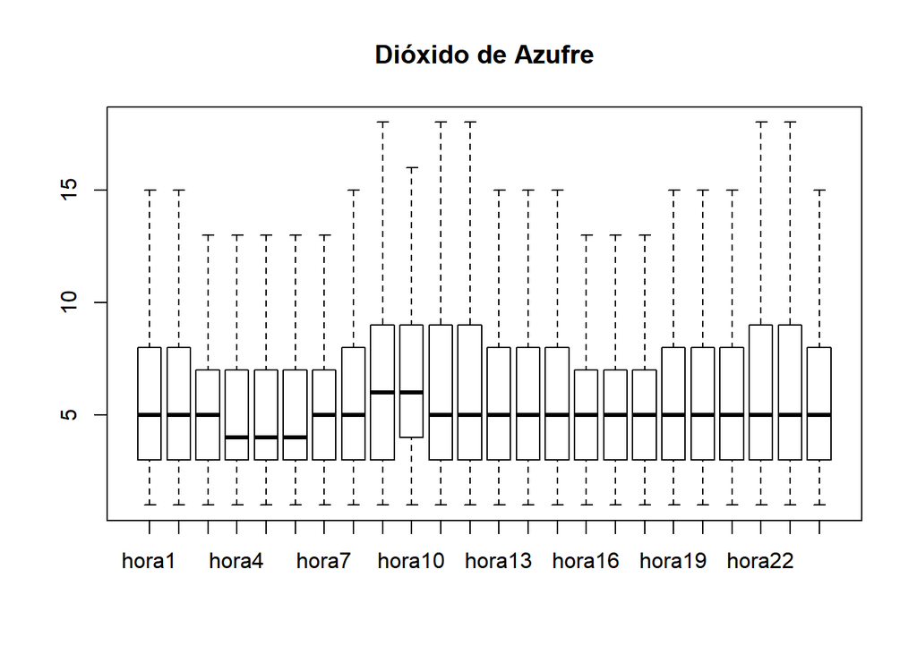

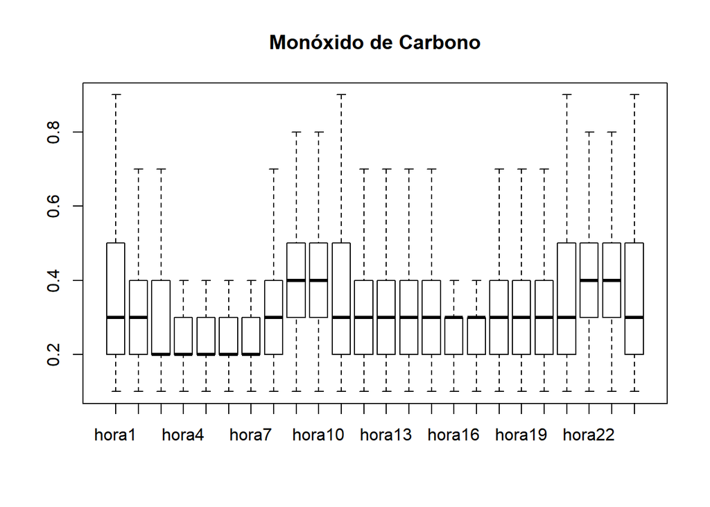

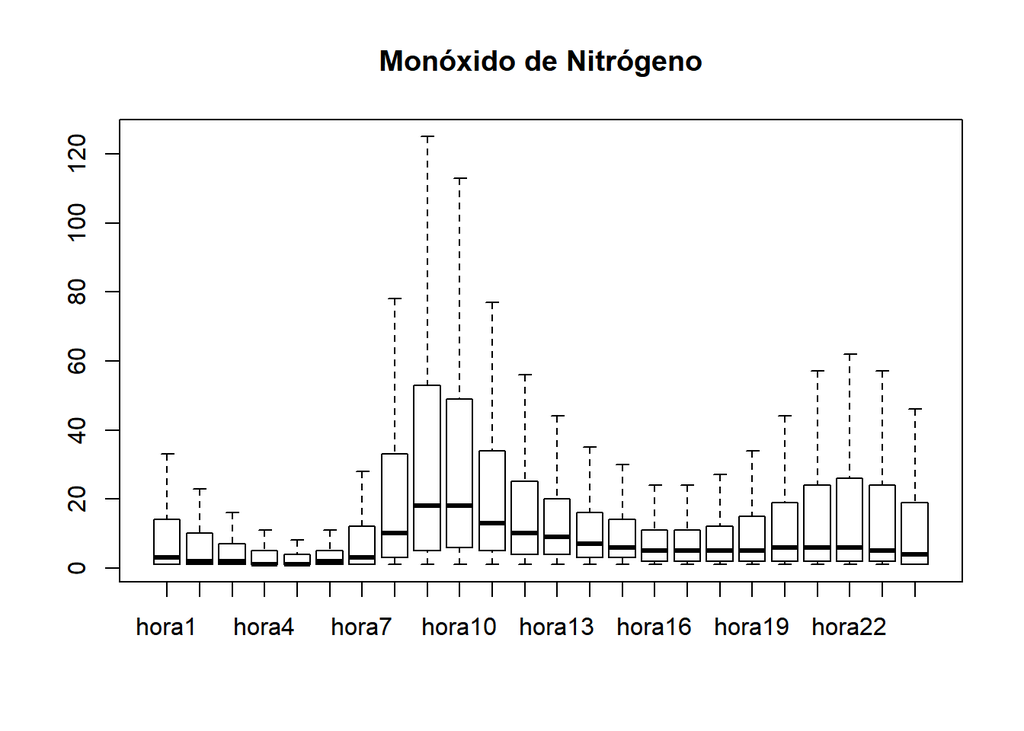

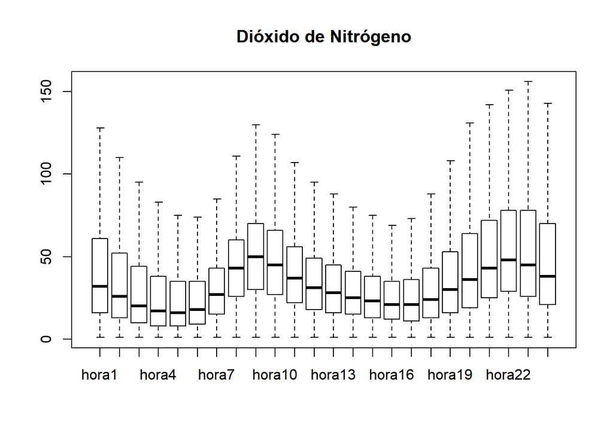

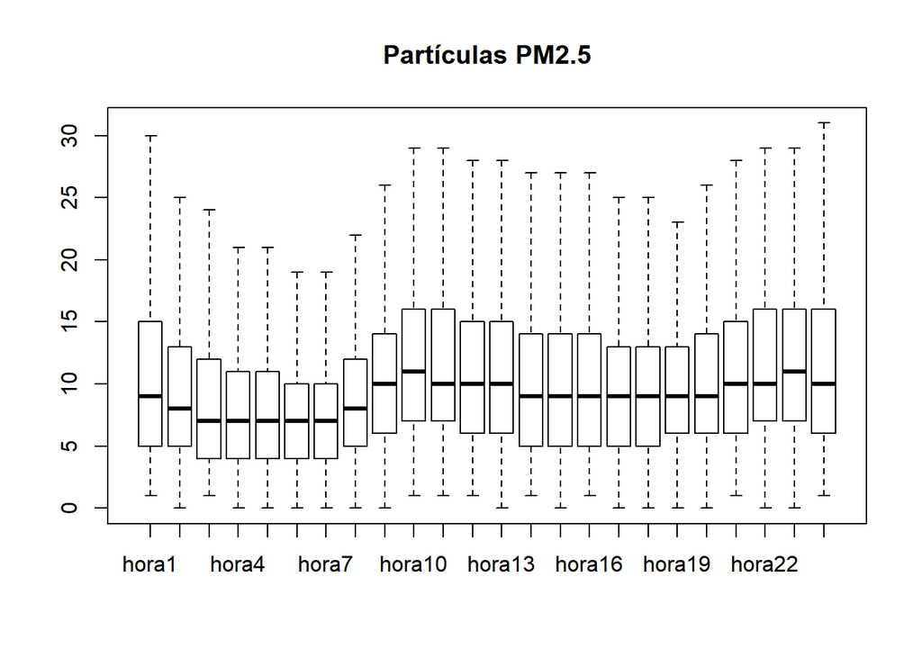

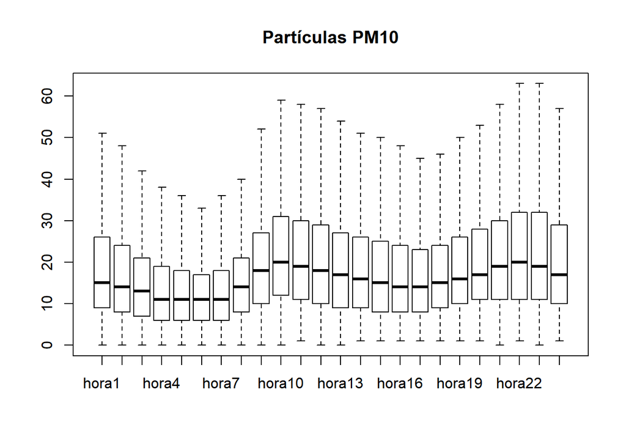

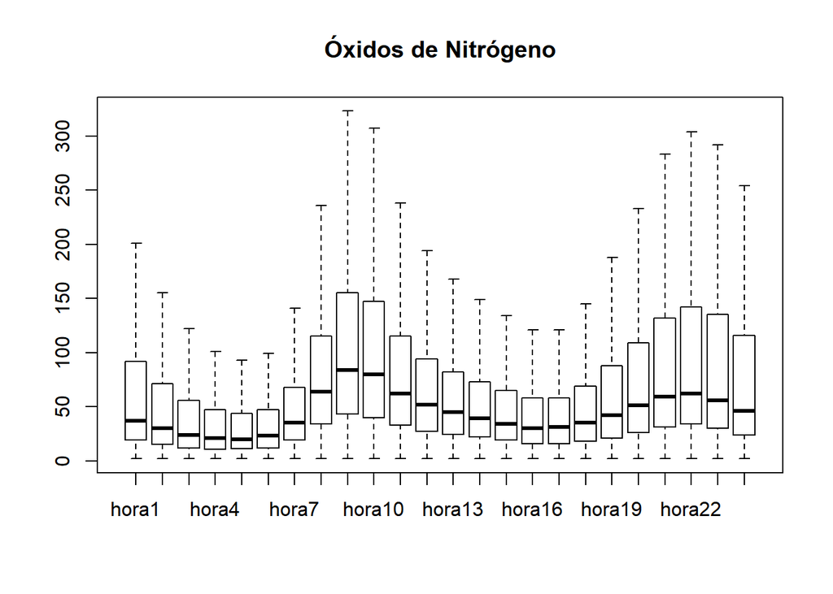

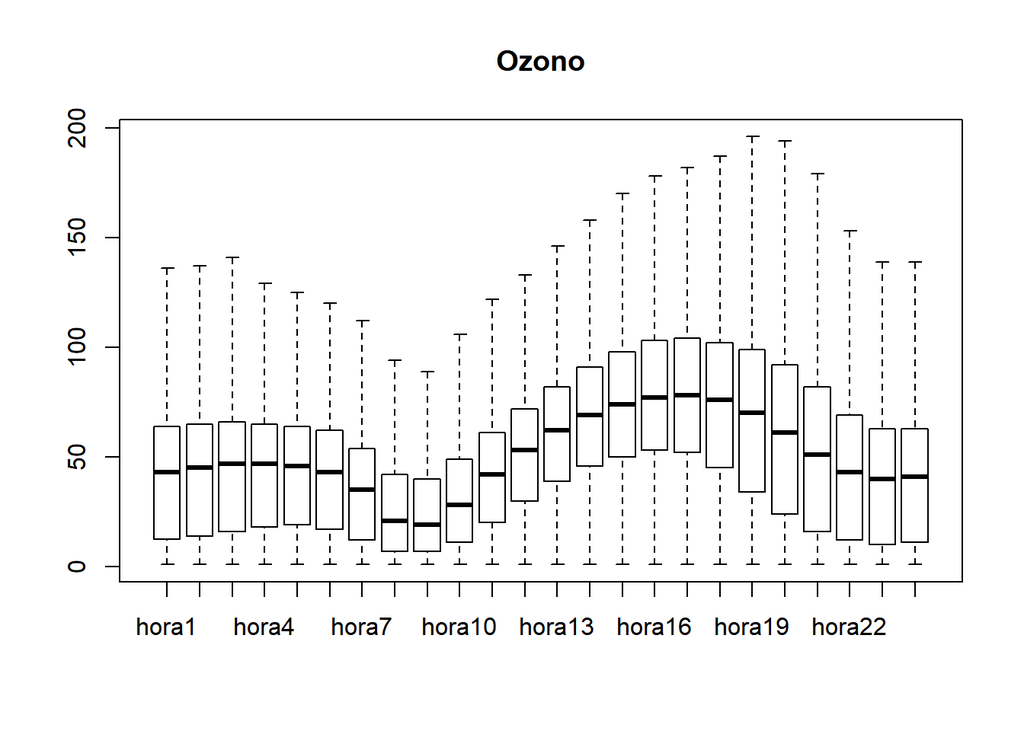

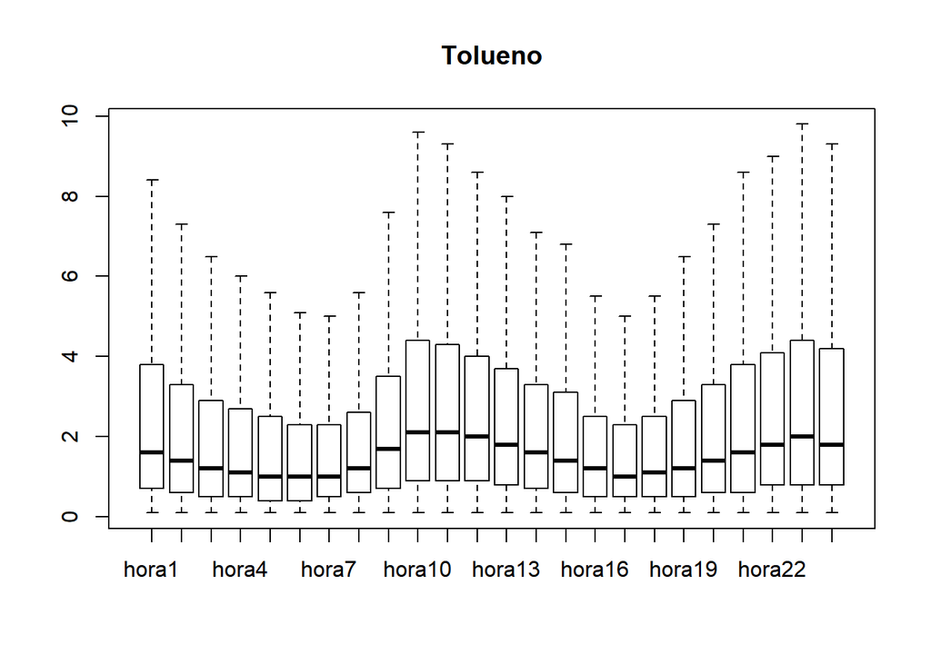

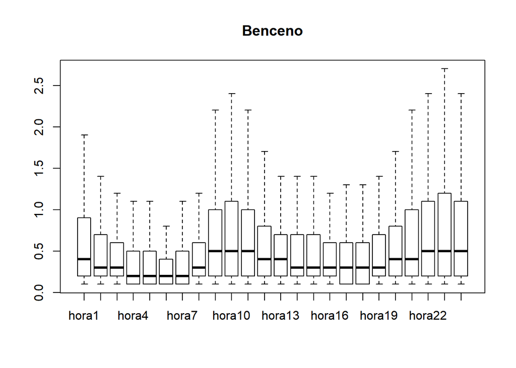

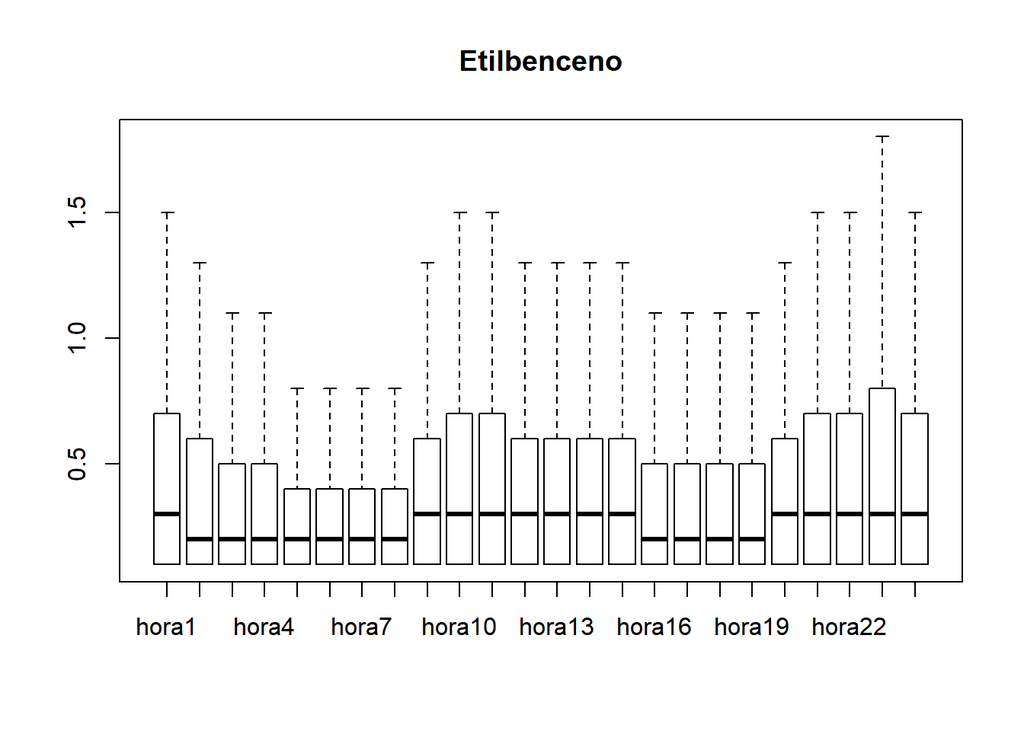

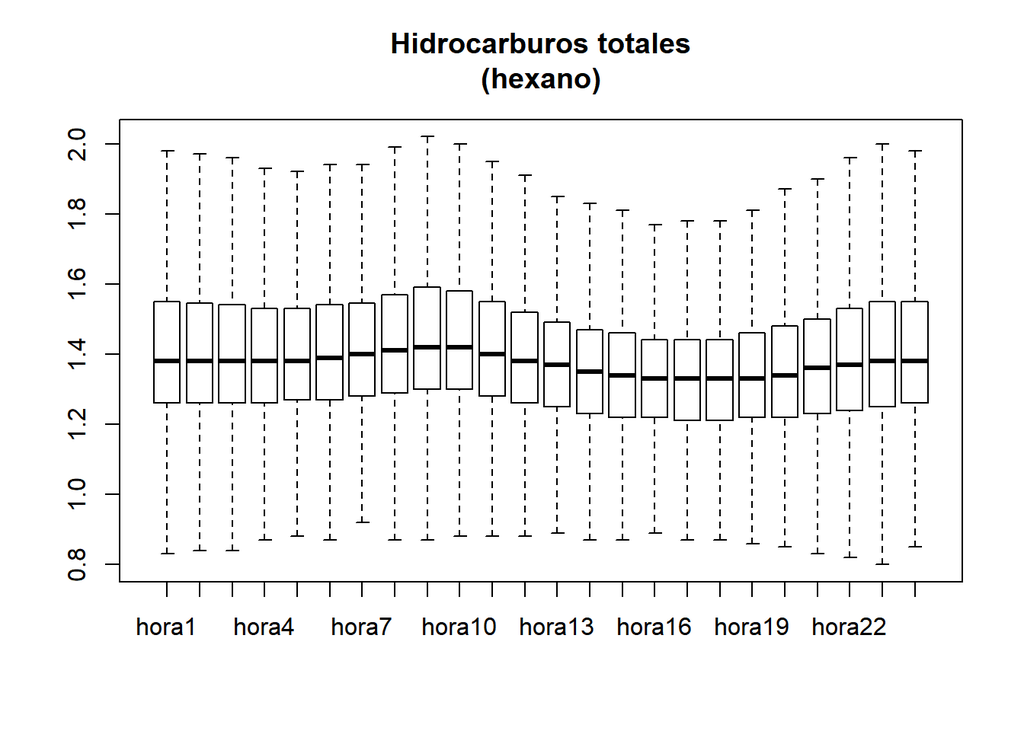

[2 more figures not shown]

```r
contaminante = c("Dióxido de Azufre","Monóxido de Carbono","Monóxido de Nitrógeno","Dióxido de Nitrógeno","Partículas PM2.5","Partículas PM10","Óxidos de Nitrógeno","Ozono","Tolueno","Benceno","Etilbenceno","Hidrocarburos totales
(hexano)","Metano","Hidrocarburos
no metánicos (hexano)")

j=1

# Boxplot mediciones de calidadAire
for (i in levels(calidadAire$contaminante)){
  boxplot(calidadAire[calidadAire$contaminante==i,6:29], main=contaminante[j], outline = FALSE)
  j=j+1
}
```

#### 1.2.2. Meteorología

```r
# str()
str(clima)
```

```
## 'data.frame':    2196 obs. of  19 variables:
##  $ altitud    : int  667 667 667 667 667 667 667 667 667 667 ...
##  $ dir        : int  27 2 8 5 22 NA 28 7 4 4 ...
##  $ fecha      : Date, format: "2013-01-01" "2013-01-02" ...
##  $ horaPresMax: chr  "24" "24" "24" "00" ...
##  $ horaPresMin: chr  "05" "00" "00" "18" ...
##  $ horaRacha  : chr  "02:20" "13:40" "11:00" "04:50" ...
##  $ horaTmax   : chr  "15:35" "13:20" "15:20" "15:40" ...
##  $ horaTmin   : chr  "00:00" "07:30" "05:50" "08:55" ...
##  $ indicativo : Factor w/ 1 level "3195": 1 1 1 1 1 1 1 1 1 1 ...
##  $ nombre     : Factor w/ 1 level "MADRID, RETIRO": 1 1 1 1 1 1 1 1 1 1 ...
##  $ prec       : num  0 0 0 0 0 0 0 0 0.4 0 ...
##  $ presMax    : num  946 950 960 960 957 ...
##  $ presMin    : num  940 946 950 957 953 ...
##  $ provincia  : Factor w/ 1 level "MADRID": 1 1 1 1 1 1 1 1 1 1 ...
##  $ racha      : num  5.8 10.3 7.5 4.2 3.6 NA 3.1 5.8 6.4 6.4 ...
##  $ tmax       : num  9.4 10.8 10.8 10.8 10.2 9.5 4.8 4.2 5.6 10.7 ...
##  $ tmed       : num  6.4 5.8 6.8 6.2 4.9 5.1 3.2 2.3 3 7.8 ...
##  $ tmin       : num  3.4 0.7 2.8 1.6 -0.4 0.7 1.5 0.4 0.4 4.8 ...
##  $ velMedia   : num  1.1 0.6 0.8 0.6 0.6 0.6 0 1.4 0.3 0.8 ...
```

```r
# summary()
summary(clima)
```

```
##     altitud         dir            fecha            horaPresMax
##  Min.   :667   Min.   : 1.00   Min.   :2013-01-01   Length:2196
##  1st Qu.:667   1st Qu.: 4.00   1st Qu.:2014-07-01   Class :character
##  Median :667   Median :19.00   Median :2015-12-31   Mode  :character
##  Mean   :667   Mean   :18.76   Mean   :2015-12-31
##  3rd Qu.:667   3rd Qu.:26.00   3rd Qu.:2017-07-01
##  Max.   :667   Max.   :99.00   Max.   :2018-12-31
##                NA's   :36
##  horaPresMin         horaRacha           horaTmax
##  Length:2196        Length:2196        Length:2196
##  Class :character   Class :character   Class :character
##  Mode  :character   Mode  :character   Mode  :character
##
##
##
##
##    horaTmin         indicativo             nombre          prec
##  Length:2196        3195:2196   MADRID, RETIRO:2196   Min.   : 0.000
##  Class :character                                     1st Qu.: 0.000
##  Mode  :character                                     Median : 0.000
##                                                       Mean   : 1.102
##                                                       3rd Qu.: 0.000
##                                                       Max.   :38.900
##
##     presMax         presMin       provincia        racha
##  Min.   :917.9   Min.   :907.3   MADRID:2196   Min.   : 1.900
##  1st Qu.:939.8   1st Qu.:935.5                 1st Qu.: 6.700
##  Median :942.8   Median :938.7                 Median : 8.900
##  Mean   :943.0   Mean   :938.7                 Mean   : 9.093
##  3rd Qu.:946.3   3rd Qu.:942.2                 3rd Qu.:11.100
##  Max.   :967.3   Max.   :962.3                 Max.   :26.100
##  NA's   :37      NA's   :37                    NA's   :36
##       tmax            tmed           tmin          velMedia
##  Min.   : 2.80   Min.   : 0.4   Min.   :-3.00   Min.   :0.000
##  1st Qu.:13.00   1st Qu.: 9.0   1st Qu.: 5.20   1st Qu.:1.100
##  Median :20.20   Median :15.3   Median :10.40   Median :1.700
##  Mean   :21.06   Mean   :16.0   Mean   :10.93   Mean   :1.846
##  3rd Qu.:28.80   3rd Qu.:22.7   3rd Qu.:16.60   3rd Qu.:2.500
##  Max.   :40.00   Max.   :32.9   Max.   :25.90   Max.   :6.400
##  NA's   :2       NA's   :2      NA's   :2       NA's   :24
```

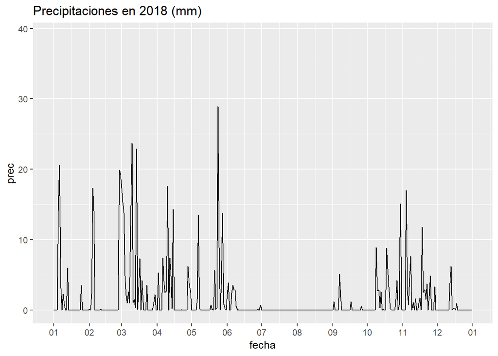

```r
# Gráficos
library(ggplot2)

# Precipitaciones
ggplot(data = clima, aes(fecha, prec)) + geom_line() + scale_x_date(date_breaks = "1 month", date_labels = "%m", limits=as.Date(c('2018-01-01','2018-12-31'))) + ggtitle("Precipitaciones en 2018 (mm)")
```

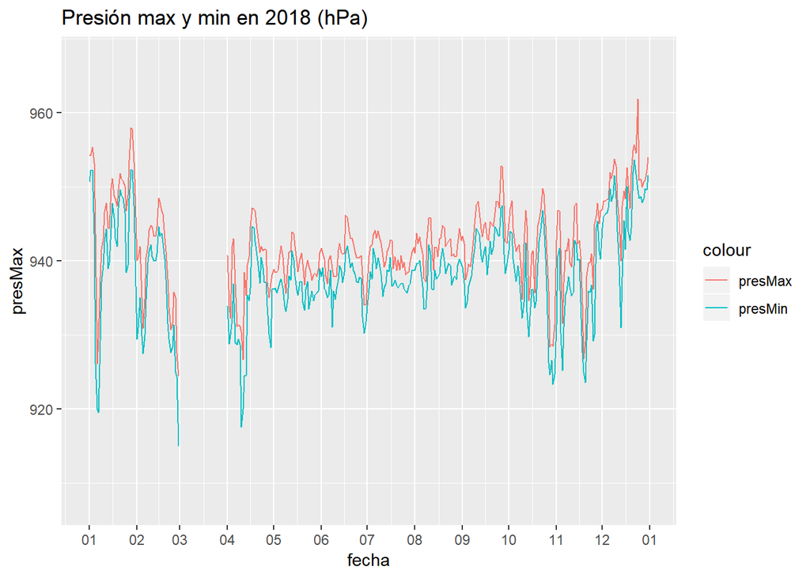

```r
# Presión atmosférica
ggplot(data = clima, aes(fecha)) + geom_line(aes(y = presMax, colour = "presMax")) + geom_line(aes(y = presMin, colour = "presMin")) + scale_x_date(date_breaks = "1 month", date_labels = "%m", limits=as.Date(c('2018-01-01','2018-12-31'))) + ggtitle("Presión max y min en 2018 (hPa)")
```

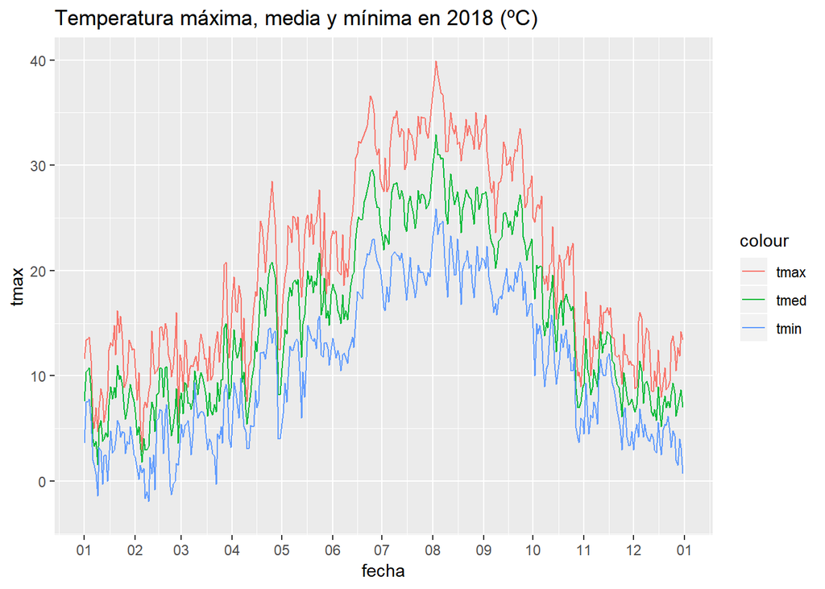

```r
# Temperatura
ggplot(data = clima, aes(fecha)) + geom_line(aes(y = tmax, colour = "tmax")) + geom_line(aes(y = tmed, colour = "tmed")) + geom_line(aes(y = tmin, colour = "tmin")) + scale_x_date(date_breaks = "1 month", date_labels = "%m", limits=as.Date(c('2018-01-01','2018-12-31'))) + ggtitle("Temperatura máxima, media y mínima en 2018 (ºC)")
```

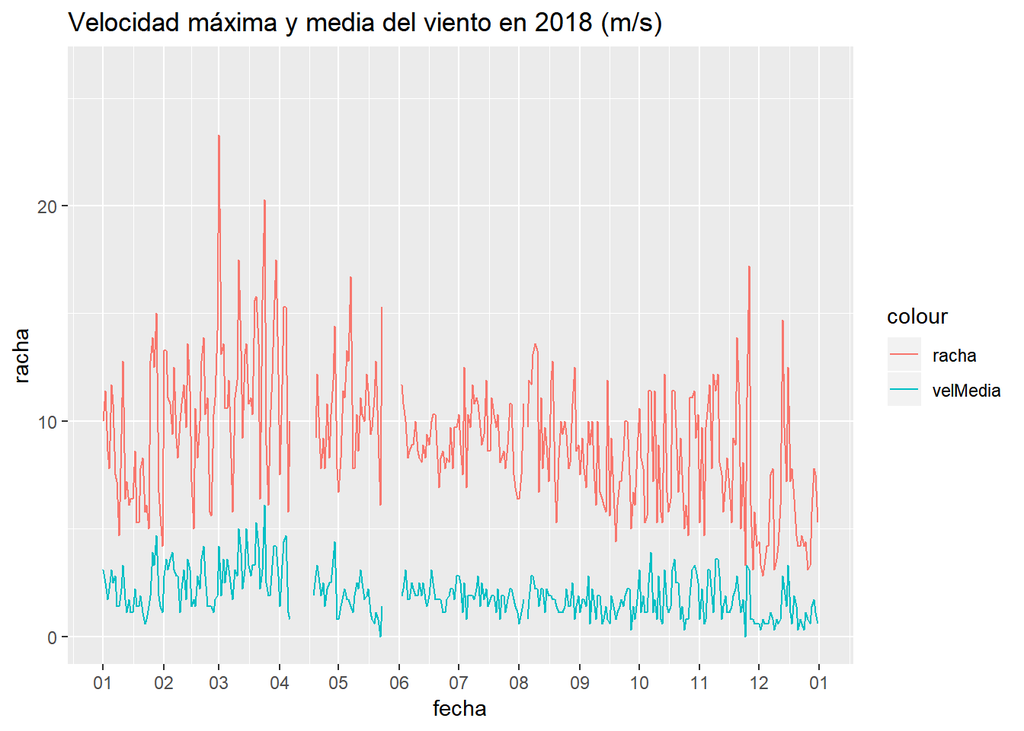

```r
# Viento
ggplot(data = clima, aes(fecha)) + geom_line(aes(y = racha, colour = "racha")) + geom_line(aes(y = velMedia, colour = "velMedia")) + scale_x_date(date_breaks = "1 month", date_labels = "%m", limits=as.Date(c('2018-01-01','2018-12-31'))) + ggtitle("Velocidad máxima y media del viento en 2018 (m/s)")
```

#### 1.2.3. Calendario laboral

```r
# str()
str(calendario)
```

```
## 'data.frame':    2555 obs. of  5 variables:
##  $ fecha      : Date, format: "2013-01-01" "2013-01-02" ...
##  $ diaSemana  : Factor w/ 7 levels "domingo","jueves",..: 4 5 2 7 6 1 3 4 5 2 ...
##  $ tipoDia    : Factor w/ 4 levels "laborable","domingo",..: 3 1 1 1 4 2 3 1 1 1 ...
##  $ tipoFestivo: Factor w/ 4 levels "","Festivo de la Comunidad de Madrid",..: 4 1 1 1 1 1 4 1 1 1 ...
##  $ festividad : Factor w/ 28 levels "","Año Nuevo",..: 2 1 1 1 1 1 23 1 1 1 ...
```

```r
# summary()
summary(calendario)
```

```
##      fecha                diaSemana        tipoDia
##  Min.   :2013-01-01   domingo  :365   laborable:1738
##  1st Qu.:2014-10-01   jueves   :365   domingo  : 359
##  Median :2016-07-02   lunes    :364   festivo  : 103
##  Mean   :2016-07-01   martes   :366   sabado   : 355
##  3rd Qu.:2018-04-01   miércoles:365
##  Max.   :2019-12-31   sábado   :365
##                       viernes  :365
##                                tipoFestivo
##                                      :2452
##  Festivo de la Comunidad de Madrid   :  20
##  Festivo local de la ciudad de Madrid:  14
##  Festivo nacional                    :  69
##
##
##
##                                          festividad
##                                               :2452
##  Asuncion de la Virgen                        :   7
##  Dos de Mayo. Fiesta de la Comunidad de Madrid:   7
##  Fiesta del Trabajo                           :   7
##  Jueves Santo                                 :   7
##  Todos los Santos                             :   7
##  (Other)                                      :  68
```

### 1.3. Preparación de los datos

#### 1.3.1. Seleccionar e integrar los datos

A continuación se seleccionan los datos deseados para constuir el modelo de predicción de la calidad del aire. Los datos seleccionados se integrarán en un nuevo data frame uniendo todos los datos de una misma fecha.

Del data frame “calidadAire” se seleccionarán los datos correspondientes a la fecha de la medida, la estación, el contaminante medido y las 24 medidas horarias. Del data frame “clima” se seleccionará la fecha y los datos de medidas de precipitación, presión máxima y mínima, temperatura máxima, mínima y media, y velocidad media y máxima del viento. Por último, del data frame “calendario” se seleccionará la fecha y si ese dia es fesitivo o no.

```r
# Seleccionamos los datos del data frame calidadAire y creamos un data frame nuevo
datos <- calidadAire[,c("estacion","fecha","contaminante","hora1","hora2","hora3","hora4","hora5","hora6","hora7","hora8","hora9","hora10","hora11","hora12","hora13","hora14","hora15","hora16","hora17","hora18","hora19","hora20","hora21","hora22","hora23","hora24")]

# Uniremos los data frames como data table
require(data.table)
setDT(datos)

# Unimos los datos seleccionados del data frame clima según la fecha de las mediciones
datos<-datos[clima[,c("fecha","prec","presMax","presMin","tmax","tmed","tmin","racha","velMedia")], on = "fecha"]

# Unimos los datos seleccionados del data frame calendario según la fecha de las mediciones
datos<-datos[calendario[calendario$fecha<'2019-01-01',c("fecha","tipoDia")], on = "fecha"]

# Reconvertimos la data table en data frame
datos<-as.data.frame(datos)
```

Una vez integrados los datos en el data frame “datos” se realizarán las siguientes transformaciones:

```r
# Sustituimos el nombre del campo "festivo" por "laborable"
colnames(datos)[36]<-"laborable"

# Codificamos el campo laborable
levels(datos$laborable)<-c(1,0,0,0)

# Cambiamos el tipo de dato del campo laborable a numérico
datos$laborable<-as.numeric(levels(datos$laborable)[datos$laborable])
```

- Se imputa a los valores perdidos (NA) el valor de la media aritmética del resto de valores observados. Para los datos vacíos de las medidas de calidad del aire, se les imputa la media de los valores recogidos para dicho contaminante en esa misma franja horaria y en el caso de los datos vacíos en las mediciones de climatología, se les imputa la media de los valores recogidos ese mismo día en el resto de años.

```r
# Medidas de contaminación: imputamos a los datos vacíos el valor medio recogido para ese contaminante en cada franja horaria
for (i in levels(datos$contaminante)) {
  for (j in levels(datos$estacion)) {
    for (k in colnames(datos)[4:27]) {
      temp<-is.na(datos[[k]])
      if (nrow(datos[temp & datos$contaminante==i & datos$estacion==j,][k]) != 0) {
        datos[temp & datos$contaminante==i & datos$estacion==j,][k] <- mean(data.matrix(datos[datos$contaminante==i & datos$estacion==j,][k]), na.rm = TRUE)
      }
      rm(temp)
    }
  }
}

# Medidas de climatología: imputamos a los datos vacíos el valor medio recogido ese mismo día en el resto de años
for (i in colnames(datos)[28:35]) {
    temp<-is.na(datos[[i]])
    unique = unique(datos[temp,2])
    if (length(unique)!=0) {
        for (j in 1:length(unique)) {
            suma = 0
            num = 0
            fecha=unique[j]
            for (k in 2013:2018) {
                replacement = paste0(k, "-")
                fecha=gsub("\\d\\d\\d\\d-*", replacement,fecha)
                valor = datos[datos$fecha==fecha,i][1]
                if (!(is.na(valor))) {
                    suma = suma + valor
                    num = num + 1
                }
            }
            media = suma / num
            datos[temp&datos$fecha==unique[j],i]<-media
        }
    }
}

# Guardamos los datos
write.csv(datos, file = "datos.csv", row.names = FALSE)
```

Realizamos una nueva exploración de los datos una vez imputado a los valores perdidos (NA) el valor de la media aritmética del resto de valores observados

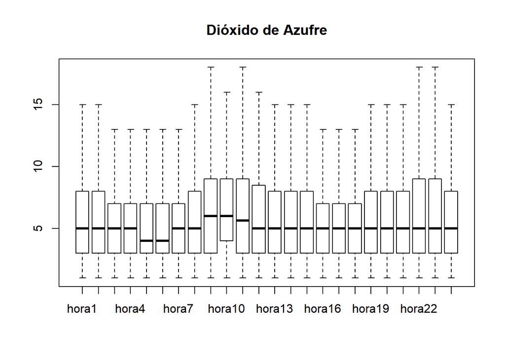

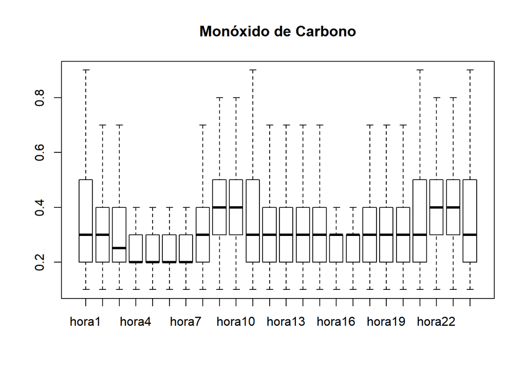

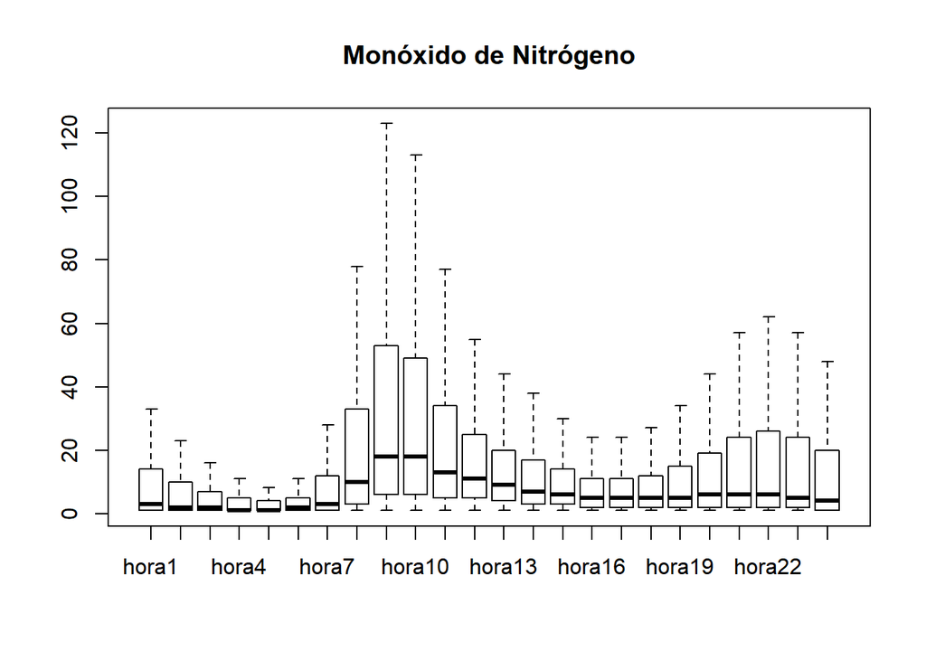

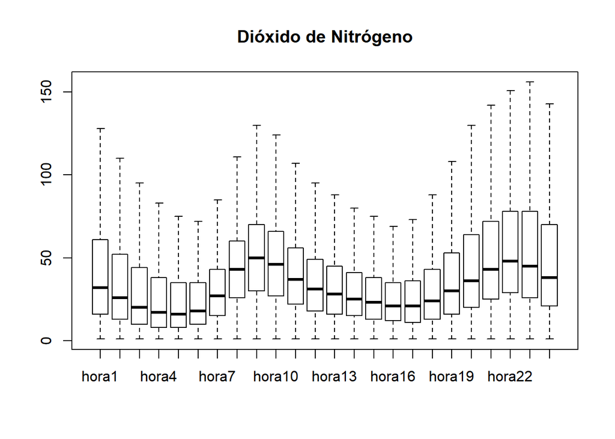

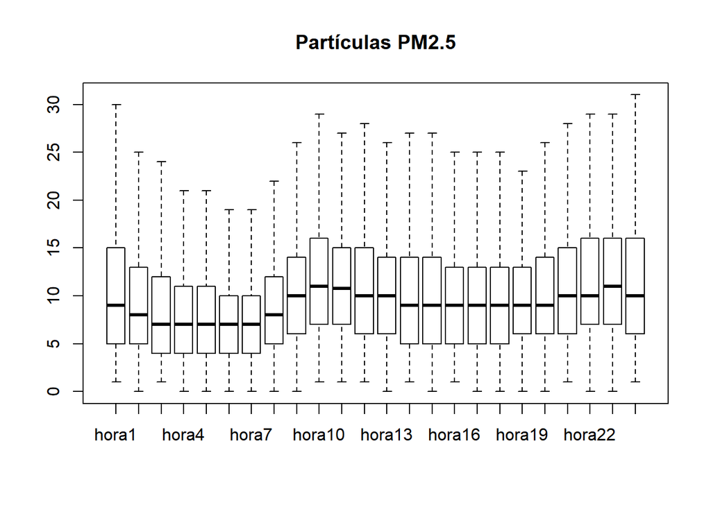

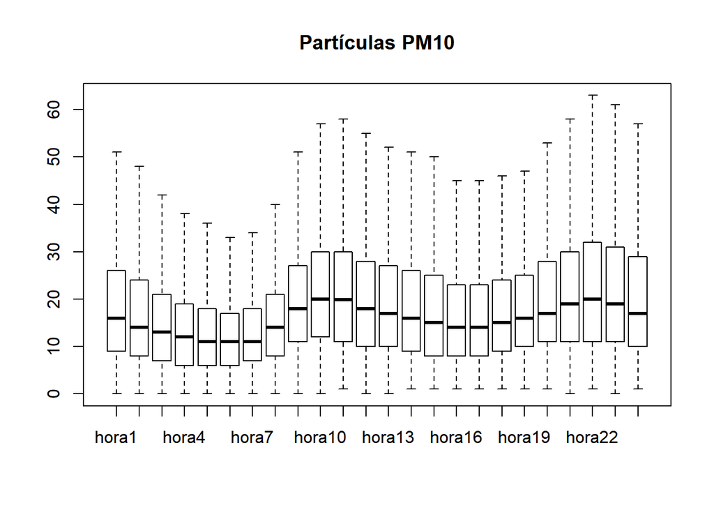

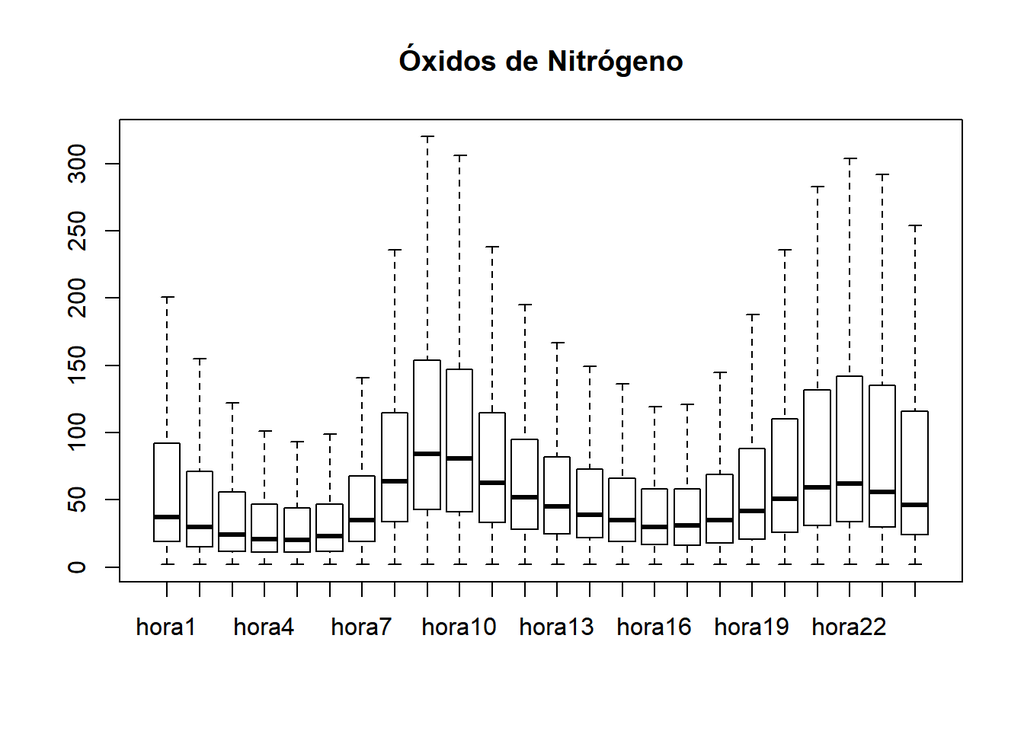

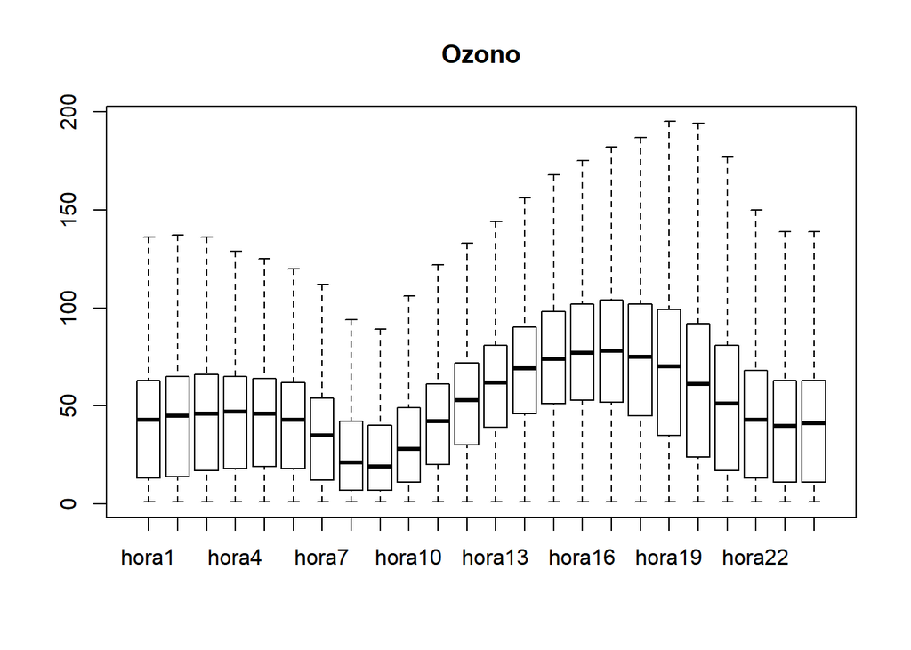

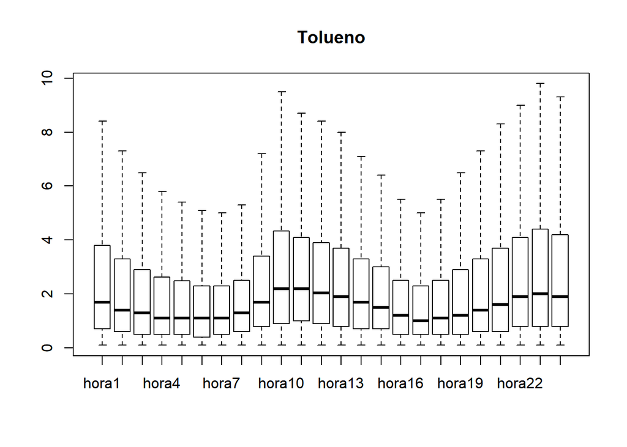

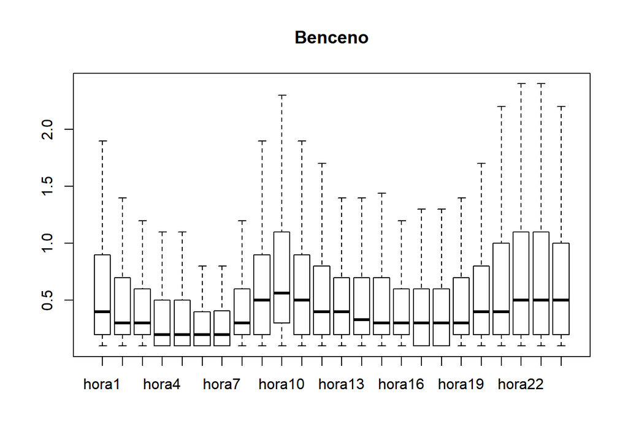

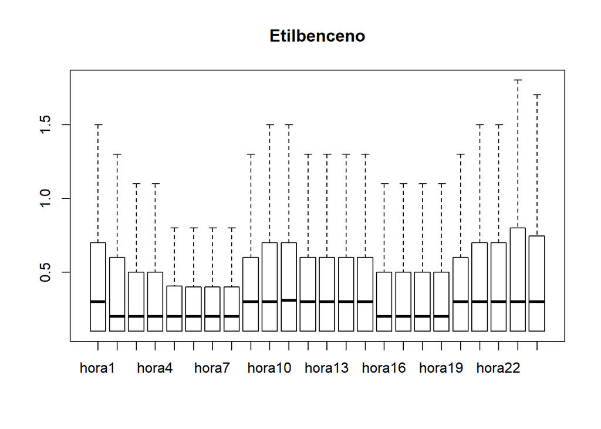

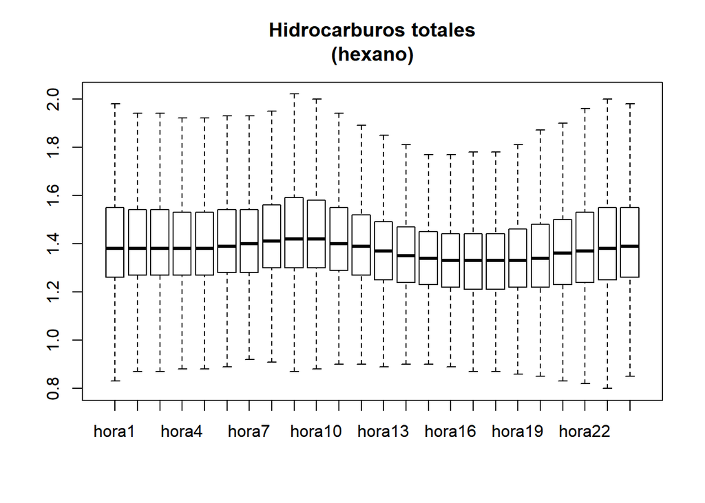

[2 more figures not shown]

```r
j=1

# Boxplot datos contaminación
for (i in levels(datos$contaminante)){
  boxplot(datos[datos$contaminante==i,4:27], main=contaminante[j], outline = FALSE)
  j=j+1
}
```

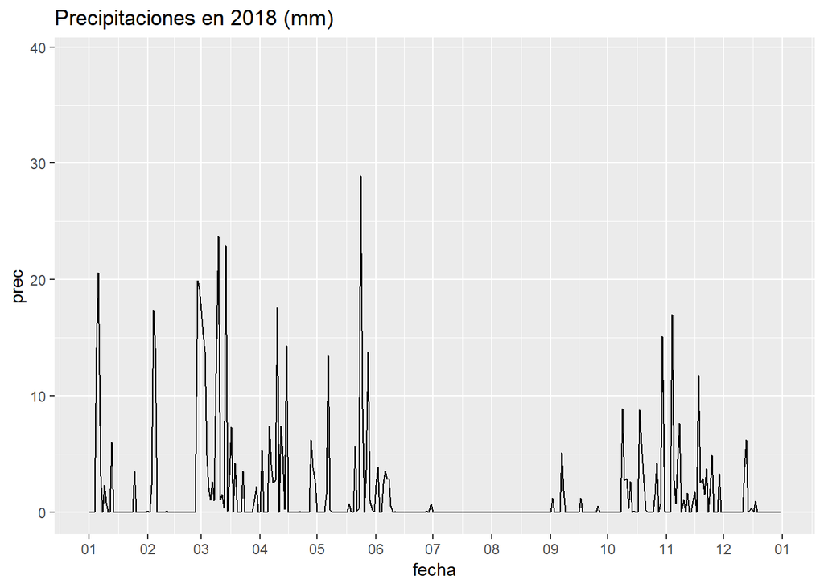

```r
# Gráficos
library(ggplot2)

# Precipitaciones
ggplot(data = datos, aes(fecha, prec)) + geom_line() + scale_x_date(date_breaks = "1 month", date_labels = "%m", limits=as.Date(c('2018-01-01','2018-12-31'))) + ggtitle("Precipitaciones en 2018 (mm)")
```

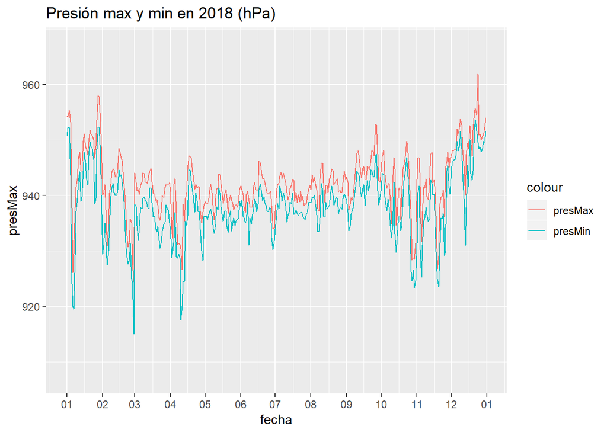

```r
# Presión atmosférica
ggplot(data = datos, aes(fecha)) + geom_line(aes(y = presMax, colour = "presMax")) + geom_line(aes(y = presMin, colour = "presMin")) + scale_x_date(date_breaks = "1 month", date_labels = "%m", limits=as.Date(c('2018-01-01','2018-12-31'))) + ggtitle("Presión max y min en 2018 (hPa)")
```

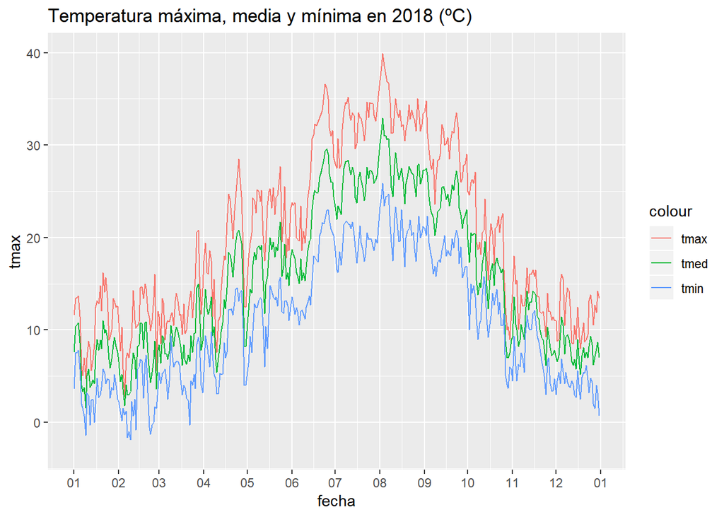

```r
# Temperatura
ggplot(data = datos, aes(fecha)) + geom_line(aes(y = tmax, colour = "tmax")) + geom_line(aes(y = tmed, colour = "tmed")) + geom_line(aes(y = tmin, colour = "tmin")) + scale_x_date(date_breaks = "1 month", date_labels = "%m", limits=as.Date(c('2018-01-01','2018-12-31'))) + ggtitle("Temperatura máxima, media y mínima en 2018 (ºC)")
```

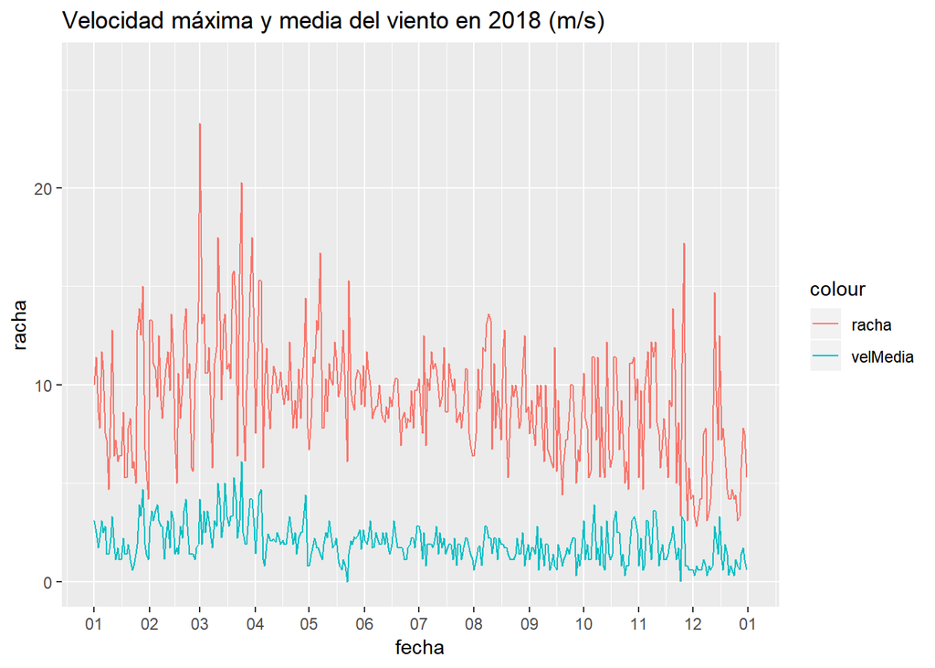

```r
# Viento
ggplot(data = datos, aes(fecha)) + geom_line(aes(y = racha, colour = "racha")) + geom_line(aes(y = velMedia, colour = "velMedia")) + scale_x_date(date_breaks = "1 month", date_labels = "%m", limits=as.Date(c('2018-01-01','2018-12-31'))) + ggtitle("Velocidad máxima y media del viento en 2018 (m/s)")
```

- Se incluye una columna con la media y otra con el máximo de las mediciones horarias de contaminación en esa estación para cada día

```r
# Calculamos el nivel medio de contaminación en cada estación para cada día
datos <- transform(datos, media = rowMeans(data.matrix(datos[,4:27])))

# Cargamos la librería matrixStats para usar la función rowMaxs
library(matrixStats)

# Calculamos el nivel máximo de contaminación en cada estación para cada día
datos <- transform(datos, maximo = rowMaxs(data.matrix(datos[,4:27])))

# Reordenamos las columnas
datos<-datos[,c("estacion","fecha","contaminante","hora1","hora2","hora3","hora4","hora5","hora6","hora7","hora8","hora9","hora10","hora11","hora12","hora13","hora14","hora15","hora16","hora17","hora18","hora19","hora20","hora21","hora22","hora23","hora24","media","maximo","prec","presMax","presMin","tmax","tmed","tmin","racha","velMedia","laborable")]

# Guardamos los datos
write.csv(datos, file = "datos.csv", row.names = FALSE)
```

Una vez integrados y preparados los datos necesarios para construir el modelo, es conveniente normalizar los datos. La normalización consiste en modificar los datos para lograr que estén en una escala de valores equivalente, de forma que se simplifique la comparación entre ellos. Si los datos no se normalizan, los métodos de minería de datos que se utilicen tenderán a quedar sesgados debido a la influencia de los atributos con valores más altos, distorsionando el resultado del modelo.

En este caso se hará uso de el método de “Normalización por la diferencia”. Este método intenta compensar el efecto que provoca la distancia del valor que se trata con respecto al máximo de los valores observados. Su fórmula de cálculo es:

$$z_i = \frac {x_i - x_{min}} {x_{max} - x_{min}}$$

A continuación preparamos una función para normalizar los datos antes de entrenar nuestro modelo. La función tendrá como entrada una lista con los datos X e Y seleccionados para entrenar o testear el modelo. La función se encargará de normalizar los datos mediante la técnica de “Normalización por la diferencia” y devolverá los datos X e Y normalizados y los valores máximo y mínimo para que sea posible revertir el proceso desnormalizando los datos.

```r
normalizar <- function(dataList) {

  # Normalizamos los datos entre 0 y 1

  if (typeof(dataList$X_train) == "list") {
    # X_train y X_test contienen varios predictores

    # Calculamos los máximos y mínimos de cada predictor
    dataList$maxXTrain = sapply(dataList$X_train, max)
    dataList$minXTrain = sapply(dataList$X_train, min)
    dataList$maxXTest = sapply(dataList$X_test, max)
    dataList$minXTest = sapply(dataList$X_test, min)

    # Normalizamos cada columna
    for (i in 1:length(dataList$X_train)) {

      dataList$X_train[,i] <- (dataList$X_train[,i] - dataList$minXTrain[i]) / (dataList$maxXTrain[i] - dataList$minXTrain[i])
      dataList$X_test[,i] <- (dataList$X_test[,i] - dataList$minXTest[i]) / (dataList$maxXTest[i] - dataList$minXTest[i])

    }

  } else {

    # X_train y X_test contienen un único predictor

    # Calculamos el máximo y el mínimo del predictor
    dataList$maxXTrain = max(dataList$X_train)
    dataList$minXTrain = min(dataList$X_train)
    dataList$maxXTest = max(dataList$X_test)
    dataList$minXTest = min(dataList$X_test)

    # Normalizamos los datos
    dataList$X_train <- (dataList$X_train - dataList$minXTrain) / (dataList$maxXTrain - dataList$minXTrain)
    dataList$X_test <- (dataList$X_test - dataList$minXTest) / (dataList$maxXTest - dataList$minXTest)

  }

  # Calculamos el máximo y el mínimo de la variable objetivo
  dataList$maxYTrain = max(dataList$Y_train)
  dataList$minYTrain = min(dataList$Y_train)
  dataList$maxYTest = max(dataList$Y_test)
  dataList$minYTest = min(dataList$Y_test)

  # Normalizamos los datos
  dataList$Y_train <- (dataList$Y_train - dataList$minYTrain) / (dataList$maxYTrain - dataList$minYTrain)
  dataList$Y_test <- (dataList$Y_test - dataList$minYTest) / (dataList$maxYTest - dataList$minYTest)

  return(dataList)

}
```

Por último, se establece una función para preparar los datos de entrenamiento y test con los que alimentar y probar los modelos.

La función tiene como entrada el código del contaminante seleccionado para el análisis, el código de la estación meteorológica de la que seleccionar los datos y el número de predictores a utilizar en la predicción (1: Sólo medidas de contaminación, 2: Medidas de contaminación y climatología y 3: Medidas de contaminación, climatología y calendario laboral).

Las observaciones del contaminante se almacenan como series temporales en X e Y, es decir, el valor de Y[i] se corresponde a la siguiente medición a X[i]. Para realizar la predicción de los niveles de alta contaminación, se ha seleccionado la medida máxima diaria recogida para el contaminante y estación seleccionados.

Los sets de entrenamiento y test se dividen en una proporción del 80% y 20% respectivamente. Después se normalizan todos los datos mediante la función creada anteriormente y se devuelven en una lista que contiene X_test, Y_test, X_train e Y_train y sus respectivos máximos y mínimos para que sea posible revertir la normalización (maxXTrain, maxXTest, maxYTrain, maxYTest, minXtrain, minXTest, minYTrain, minYTest).

```r
preparar_datos <- function(c, estacion, predictores, pred_clima) {

  # c: Código del contaminante seleccionado
  # estacion: Código de la estación a analizar
  # predictores: 1 sólo medidas de contaminación, 2 medidas de contaminación y climatología, 3 medidas de contaminación, climatología y calendario laboral
  # pred_clima: TRUE: Se usan como variables predictoras los datos del clima del día en que se quiere predecir la contaminación (uso de predicción del clima)
  # pred_clima: FALSE: Se usan como variables predictoras los datos del clima del día anterior al que se quiere predecir la contaminación

  if (is.null(c)) stop("El parámetro c (código de contaminante) es obligatorio.")
  if (is.null(estacion)) stop("El parámetro estación es obligatorio.")
  if (is.null(predictores)) stop("El parámetro preditores es obligatorio.")
  if (is.null(pred_clima)) stop("El parámetro pred_clima es obligatorio")

  if (predictores == 1) {

    # Sólo se utilizan los datos de medidas de contaminación para el contaminante c

    # Almacenamos las observaciones del contaminante c como series temporales en X e Y, siendo Y[i] la siguiente medición a X[i]
    X <- datos[datos$contaminante==c&datos$estacion==estacion,"maximo"]

    Y <- X[-1]
    X <- X[-length(X)]

    # Separamos X e Y en sets de entrenamiento y test (80% y 20% respectivamente)
    sample<-c(1:(0.8*length(X)))

    X_train <- X[sample]
    Y_train <- Y[sample]

    X_test <- X[-sample]
    Y_test <- Y[-sample]

  } else if (predictores == 2) {

    # Se utilizan los datos de medidas de contaminación y las medidas climatológicas

    if (pred_clima==TRUE) {

      # Almacenamos las observaciones del contaminante c como series temporales en X e Y, siendo Y[i,] la siguiente medición a X[i,]
      # Almacenamos en X las mediciones climatológicas del mismo día en que deseamos predecir la contaminación (uso de predicción del clima)
      X1 <- datos[datos$contaminante==c&datos$estacion==estacion,"maximo"]
      X2 <- datos[datos$contaminante==c&datos$estacion==estacion,c("prec","presMax","presMin","tmax","tmed","tmin", "racha","velMedia")]

      Y <- X1[-1]
      X <- cbind(X1,X2)
      X <- X[-nrow(X),]

    } else {

      # Almacenamos las observaciones del contaminante c como series temporales en X e Y, siendo Y[i,] la siguiente medición a X[i,]
      # Almacenamos en X las mediciones climatológicas del día anterior al que deseamos predecir la contaminación
      X <- datos[datos$contaminante==c&datos$estacion==estacion,c("maximo","prec","presMax","presMin","tmax","tmed","tmin", "racha","velMedia")]

      Y <- X[-1,"maximo"]
      X <- X[-nrow(X),]

    }

    # Separamos X e Y en sets de entrenamiento y test (80% y 20% respectivamente)
    sample<-c(1:(0.8*nrow(X)))

    X_train <- X[sample,]
    Y_train <- Y[sample]

    X_test <- X[-sample,]
    Y_test <- Y[-sample]

  } else if (predictores == 3) {

    # Se utilizan los datos de medidas de contaminación, las medidas climatológicas y el calendario laboral

    if (pred_clima==TRUE) {

      # Almacenamos las observaciones del contaminante c como series temporales en X e Y, siendo Y[i,] la siguiente medición a X[i,]
      # Almacenamos en X las mediciones climatológicas del mismo día en que deseamos predecir la contaminación (uso de predicción del clima)
      X1 <- datos[datos$contaminante==c&datos$estacion==estacion,"maximo"]
      X2 <- datos[datos$contaminante==c&datos$estacion==estacion,c("prec","presMax","presMin","tmax","tmed","tmin", "racha","velMedia","laborable")]

      Y <- X1[-1]
      X <- cbind(X1,X2)
      X <- X[-nrow(X),]

    } else {

      # Almacenamos las observaciones del contaminante c como series temporales en X e Y, siendo Y[i,] la siguiente medición a X[i,]
      # Almacenamos en X las mediciones climatológicas del día anterior al que deseamos predecir la contaminación
      X1 <- datos[datos$contaminante==c&datos$estacion==estacion,c("maximo","prec","presMax","presMin","tmax","tmed","tmin", "racha","velMedia")]
      X2 <- datos[datos$contaminante==c&datos$estacion==estacion,"laborable"]

      Y <- X1[-1,"maximo"]
      X1 <- X1[-nrow(X1),]
      X2 <- X2[-1]
      X <- cbind(X1,X2)

    }

    # Separamos X e Y en sets de entrenamiento y test (80% y 20% respectivamente)
    sample<-c(1:(0.8*nrow(X)))

    X_train <- X[sample,]
    Y_train <- Y[sample]

    X_test <- X[-sample,]
    Y_test <- Y[-sample]

  }

  # Almacenamos los sets de datos en una lista (facilita el return de la función)
  returnList <- list("X_train" = X_train, "Y_train" = Y_train, "X_test" = X_test, "Y_test" = Y_test)

  # Normalizamos los datos
  returnList <- normalizar(returnList)

  return(returnList)

}
```

```r
j=1

for (i in levels(datos$contaminante)) {
  print(paste0("Correlación de atributos para el contamiante: ", contaminante[j]))
  print(cor(datos[datos$contaminante==i,28:37])[,"media"])
  cat("\n")
  j=j+1
}
```

```
## [1] "Correlación de atributos para el contamiante: Dióxido de Azufre"
##       media      maximo        prec     presMax     presMin        tmax
##  1.00000000  0.86208629 -0.04522218  0.28342088  0.25903635 -0.21866577
##        tmed        tmin       racha    velMedia
## -0.23535612 -0.25082764 -0.23368083 -0.22871207
##
## [1] "Correlación de atributos para el contamiante: Monóxido de Carbono"
##       media      maximo        prec     presMax     presMin        tmax
##  1.00000000  0.84618192 -0.06753177  0.40718301  0.38383159 -0.34042134
##        tmed        tmin       racha    velMedia
## -0.36671638 -0.39131211 -0.42253677 -0.41215539
##
## [1] "Correlación de atributos para el contamiante: Monóxido de Nitrógeno"
##       media      maximo        prec     presMax     presMin        tmax
##  1.00000000  0.90864346 -0.08471685  0.45029082  0.42797322 -0.30863680
##        tmed        tmin       racha    velMedia
## -0.33706114 -0.36542330 -0.43217655 -0.42435663
##
## [1] "Correlación de atributos para el contamiante: Dióxido de Nitrógeno"
##       media      maximo        prec     presMax     presMin        tmax
##  1.00000000  0.83780013 -0.06276642  0.40053402  0.38944258 -0.22614819
##        tmed        tmin       racha    velMedia
## -0.25420653 -0.28465405 -0.49800645 -0.49979054
##
## [1] "Correlación de atributos para el contamiante: Partículas PM2.5"
##       media      maximo        prec     presMax     presMin        tmax
##  1.00000000  0.85445752 -0.11647873  0.33403963  0.37308642  0.10425333
##        tmed        tmin       racha    velMedia
##  0.09676577  0.08360166 -0.46423605 -0.45597023
##
## [1] "Correlación de atributos para el contamiante: Partículas PM10"
##      media     maximo       prec    presMax    presMin       tmax
##  1.0000000  0.8239487 -0.1431239  0.1790577  0.2341865  0.3583803
##       tmed       tmin      racha   velMedia
##  0.3539825  0.3373705 -0.2747192 -0.2801233
##
## [1] "Correlación de atributos para el contamiante: Óxidos de Nitrógeno"
##      media     maximo       prec    presMax    presMin       tmax
##  1.0000000  0.9094987 -0.1056413  0.4165245  0.3938300 -0.2929676
##       tmed       tmin      racha   velMedia
```

[output cut: 28 more lines]

```
##  1.00000000  0.80871725 -0.02959493  0.21198726  0.19832931 -0.18371485
##        tmed        tmin       racha    velMedia
## -0.19561664 -0.20589583 -0.26747404 -0.26485777
##
## [1] "Correlación de atributos para el contamiante: Metano"
##       media      maximo        prec     presMax     presMin        tmax
##  1.00000000  0.78365509 -0.03513104  0.18274317  0.17567853 -0.10034146
##        tmed        tmin       racha    velMedia
## -0.10213686 -0.10183192 -0.26957596 -0.26615455
##
## [1] "Correlación de atributos para el contamiante: Hidrocarburos\nno metánicos (hexano)"
##       media      maximo        prec     presMax     presMin        tmax
##  1.00000000  0.81498151 -0.04468974  0.06261577  0.06458745 -0.08076446
##        tmed        tmin       racha    velMedia
## -0.09565388 -0.11274954 -0.08054685 -0.06903035
```